# Homework 1: US gun murders

September 10, 2018

#### Due: September 26th by 11:59pm

Several of your friends live in Europe and are offered jobs at a US company with many locations all across the country. The job offers are great but news with headlines such as [**US Gun Homicide Rate Higher Than Other Developed Countries**](https://abcnews.go.com/News/us-gun-ownership-homicide-rate-higher-than-other-developed-countries/blogEntry?id=18008187) have them worried. Charts like this make them worry even more:

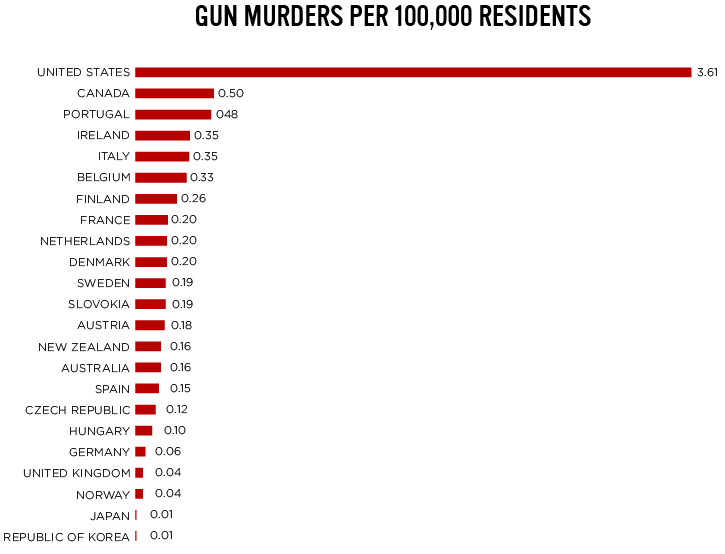

US gun homicides second chart

You want to convince your friends that the US is a large and diverse country with 50 very different states as well as the District of Columbia (DC). You want to recommend some states for each friend knowing that some like hiking, while others would like to be close to several large cosmopolitan cities. Use data from the US murders data set:

```r
library(dslabs)
data(murders)
```

1. What is the state with the most murders? Would you say this is the most dangerous state? Hint: Make a plot showing the relationship between population size and number of murders.
2. Add a column to the murder data table called `murder_rate` with each states murder rate.
3. Describe the distribution of murder rates across states. How similar are states? How much do murder rates vary by geographical regions?
4. Write a report for your friends reminding them that the US is a large and diverse country with 50 very different states as well as the District of Columbia (DC). Suppose one of your friends loves hiking, one wants to live in a warm climate, and another would like to be close to several large cosmopolitan cities. Recommend a desirable state for each friend.